# zomato

```python
import numpy as np
import pandas as pd
import matplotlib.pyplot as plt
import seaborn as sns
df = pd.read_csv('cdata.csv')
dataset = df.copy()
```

```python
df.info()
```

```
<class 'pandas.core.frame.DataFrame'>
RangeIndex: 7442 entries, 0 to 7441
Data columns (total 9 columns):
Zomato URL            7442 non-null object
Name of Restaurant    7442 non-null object
Address               7442 non-null object
Location              7442 non-null object
Cuisine               7442 non-null object
Top Dishes            7442 non-null object
Price for 2           7442 non-null int64
Ratings               7442 non-null object
No of Votes           7442 non-null object
dtypes: int64(1), object(8)
memory usage: 523.4+ KB
```

```python
df.head()
```

|  | Zomato URL | Name of Restaurant | Address | Location | Cuisine | Top Dishes | Price for 2 | Ratings | No of Votes |
| --- | --- | --- | --- | --- | --- | --- | --- | --- | --- |
| 0 | https://www.zomato.com/chennai/the-black-pearl... | The Black Pearl | Plot 155, 292/132, Ground Floor, Rajiv Gandhi... | Sholinganallur | North Indian, European, Mediterranean, Contine... | Fish,Pizza,Prawn,Jalebi,Pav Bhaji,Chaat,Mocktails | 1500 | 4.9 | 2857 |
| 1 | https://www.zomato.com/chennai/coal-barbecues-... | Coal Barbecues | 40, 2nd Floor, Bazullah Road, T. Nagar, Chennai | T. Nagar | North Indian, Mediterranean, Asian, Arabian, BBQ | Chicken Honey,Pizza,Fish,Kulfi,Chicken Wings,P... | 1400 | 4.9 | 7320 |
| 2 | https://www.zomato.com/chennai/palmshore-medav... | Palmshore | 4/581 A, Velachery Main Road, Senthamizh Naga... | Medavakkam | North Indian, Chinese, Arabian | Biryani,Faluda,Fish,Bbq Chicken,Mutton Mandi,B... | 700 | 4.5 | 441 |
| 3 | https://www.zomato.com/chennai/fromage-mrc-nagar | Fromage | Somerset Greenway, Lords Avenue, MRC Nagar, C... | MRC Nagar | Cafe, Italian, French, European | Pasta,Pork Ribs,Chicken Steak,Chocolate Cake,B... | 1000 | 4.5 | 1073 |
| 4 | https://www.zomato.com/chennai/savoury-sea-she... | Savoury Sea Shell | 3, E Block, 3rd Avenue, Anna Nagar East, Chennai | Anna Nagar East | Arabian, Chinese, North Indian, Lebanese, Salad | Shawarma,Chicken Grill,Brownie,Sea Food,Bbq Ch... | 1400 | 4.1 | 2446 |

```python
df['Ratings'].isnull()
```

```
0       False
1       False
2       False
3       False
4       False
        ...
7437    False
7438    False
7439    False
7440    False
7441    False
Name: Ratings, Length: 7442, dtype: bool
```

```python
missing_values = ["invalid"]
df = pd.read_csv("cdata.csv", na_values = missing_values)
```

```python
df.isnull().sum()
```

```
Zomato URL               0
Name of Restaurant       0
Address                  0
Location                 0
Cuisine                  0
Top Dishes               0
Price for 2              0
Ratings               2635
No of Votes           2639
dtype: int64
```

```python
df.isnull().sum().sum()
```

```
5274
```

```python
df.dropna()
```

|  | Zomato URL | Name of Restaurant | Address | Location | Cuisine | Top Dishes | Price for 2 | Ratings | No of Votes |
| --- | --- | --- | --- | --- | --- | --- | --- | --- | --- |
| 0 | https://www.zomato.com/chennai/the-black-pearl... | The Black Pearl | Plot 155, 292/132, Ground Floor, Rajiv Gandhi... | Sholinganallur | North Indian, European, Mediterranean, Contine... | Fish,Pizza,Prawn,Jalebi,Pav Bhaji,Chaat,Mocktails | 1500 | 4.9 | 2857.0 |
| 1 | https://www.zomato.com/chennai/coal-barbecues-... | Coal Barbecues | 40, 2nd Floor, Bazullah Road, T. Nagar, Chennai | T. Nagar | North Indian, Mediterranean, Asian, Arabian, BBQ | Chicken Honey,Pizza,Fish,Kulfi,Chicken Wings,P... | 1400 | 4.9 | 7320.0 |
| 2 | https://www.zomato.com/chennai/palmshore-medav... | Palmshore | 4/581 A, Velachery Main Road, Senthamizh Naga... | Medavakkam | North Indian, Chinese, Arabian | Biryani,Faluda,Fish,Bbq Chicken,Mutton Mandi,B... | 700 | 4.5 | 441.0 |
| 3 | https://www.zomato.com/chennai/fromage-mrc-nagar | Fromage | Somerset Greenway, Lords Avenue, MRC Nagar, C... | MRC Nagar | Cafe, Italian, French, European | Pasta,Pork Ribs,Chicken Steak,Chocolate Cake,B... | 1000 | 4.5 | 1073.0 |
| 4 | https://www.zomato.com/chennai/savoury-sea-she... | Savoury Sea Shell | 3, E Block, 3rd Avenue, Anna Nagar East, Chennai | Anna Nagar East | Arabian, Chinese, North Indian, Lebanese, Salad | Shawarma,Chicken Grill,Brownie,Sea Food,Bbq Ch... | 1400 | 4.1 | 2446.0 |
| ... | ... | ... | ... | ... | ... | ... | ... | ... | ... |
| 5462 | https://www.zomato.com/chennai/chitras-chat-an... | Chitra's Chat and Eat | 179/188, Sadhasivam Nagar, Madipakkam, Madhav... | Madhavaram | North Indian, South Indian | Invalid | 150 | 3.0 | 4.0 |
| 5466 | https://www.zomato.com/chennai/s-p-biriyani-fa... | S.P Biriyani & Fast Food | 119, North Redhills Road Villivakkam, Anna Na... | Anna Nagar West | Biryani | Invalid | 250 | 3.1 | 4.0 |
| 5467 | https://www.zomato.com/chennai/hotel-maniganda... | Hotel Manigandan | 402, Manickam Nagar Main Road, Tiruvottiyur, ... | Tiruvottiyur | South Indian, Chinese, Biryani | Invalid | 400 | 3.0 | 4.0 |
| 5485 | https://www.zomato.com/chennai/happy-fast-food... | Happy Fast Food | 42, Anjaneyar Kovil Street, Saidapet, Chennai | Saidapet | Chettinad, Chinese | Invalid | 250 | 3.0 | 4.0 |
| 5614 | https://www.zomato.com/chennai/chimney-roof-to... | Chimney Roof Top | Liberty Park Hotel, 9, 1st Main Road, United ... | Liberty Park Hotel, Kodambakkam | North Indian, South Indian, Chinese | Invalid | 800 | 3.0 | 2.0 |

4803 rows × 9 columns

```python
df.to_csv('updated.csv')
```

```python
df.info()
```

```
<class 'pandas.core.frame.DataFrame'>
RangeIndex: 7442 entries, 0 to 7441
Data columns (total 9 columns):
Zomato URL            7442 non-null object
Name of Restaurant    7442 non-null object
Address               7442 non-null object
Location              7442 non-null object
Cuisine               7442 non-null object
Top Dishes            7442 non-null object
Price for 2           7442 non-null int64
Ratings               4807 non-null float64
No of Votes           4803 non-null float64
dtypes: float64(2), int64(1), object(6)
memory usage: 523.4+ KB
```

```python
del df['Zomato URL']
del df['Address']
del df['Top Dishes']
```

```python
df = df.rename(columns = {"Name of Restaurant" : "restaurant_name", "No of Votes" : "Votes"})
```

```python
df.head()
```

|  | restaurant_name | Location | Cuisine | Price for 2 | Ratings | Votes |
| --- | --- | --- | --- | --- | --- | --- |
| 0 | The Black Pearl | Sholinganallur | North Indian, European, Mediterranean, Contine... | 1500 | 4.9 | 2857.0 |
| 1 | Coal Barbecues | T. Nagar | North Indian, Mediterranean, Asian, Arabian, BBQ | 1400 | 4.9 | 7320.0 |
| 2 | Palmshore | Medavakkam | North Indian, Chinese, Arabian | 700 | 4.5 | 441.0 |
| 3 | Fromage | MRC Nagar | Cafe, Italian, French, European | 1000 | 4.5 | 1073.0 |
| 4 | Savoury Sea Shell | Anna Nagar East | Arabian, Chinese, North Indian, Lebanese, Salad | 1400 | 4.1 | 2446.0 |

```python
df.to_csv('updated.csv')
```

```python
len(df['Location'].value_counts())
```

```
273
```

```python
df.head()
```

|  | restaurant_name | Location | Cuisine | Price for 2 | Ratings | Votes |
| --- | --- | --- | --- | --- | --- | --- |
| 0 | The Black Pearl | Sholinganallur | North Indian, European, Mediterranean, Contine... | 1500 | 4.9 | 2857.0 |
| 1 | Coal Barbecues | T. Nagar | North Indian, Mediterranean, Asian, Arabian, BBQ | 1400 | 4.9 | 7320.0 |
| 2 | Palmshore | Medavakkam | North Indian, Chinese, Arabian | 700 | 4.5 | 441.0 |
| 3 | Fromage | MRC Nagar | Cafe, Italian, French, European | 1000 | 4.5 | 1073.0 |
| 4 | Savoury Sea Shell | Anna Nagar East | Arabian, Chinese, North Indian, Lebanese, Salad | 1400 | 4.1 | 2446.0 |

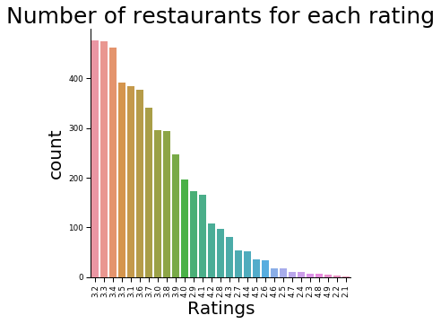

```python
sns.set_context("paper", font_scale = 1, rc = {"font.size": 20,"axes.titlesize": 25,"axes.labelsize": 20})
b = sns.catplot(data = df, kind = 'Count', x = 'Ratings', order = df['Ratings'].value_counts().index)
plt.title('Number of restaurants for each rating')
b.set_xticklabels(rotation = 90)
plt.show()
```

The majority of restaurants are rated 3.2(out of 5), followed by 3.3 and 3.4, which are pretty decent ratings. This means that most of the restaurants at Chennai are liked by the citizens and hence rated above average. There are very few restaurants with very high rating like 4.9 or 4.8.

```python
import numpy as np
import pandas as pd
import matplotlib.pyplot as plt
import seaborn as sns
df = pd.read_csv('updated.csv')
dataset = df.copy()
```

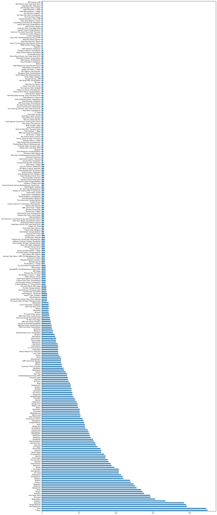

```python
import matplotlib.pyplot as plt
df['Location'].value_counts().head(7442).plot(kind='barh', figsize=(20,60))
```

T.Nagar has the highest number of restaurants, followed by Porur. IBIS Chennai,OMR has the least number of restaurants, followed by Jade Resorts,ECR. It seems that the main foodies live in T.Nagar and Porur.

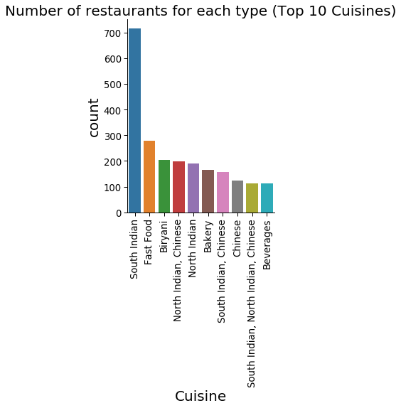

```python
sns.set_context("paper", font_scale = 1.5, rc = {"font.size": 20,"axes.titlesize": 20,"axes.labelsize": 20})
b = sns.catplot(data = df, kind = 'Count', x = 'Cuisine', order = df['Cuisine'].value_counts().head(10).index)
plt.title('Number of restaurants for each type (Top 10 Cuisines)')
b.set_xticklabels(rotation = 90)
plt.show()
```

The most number of restaurants are of the type South Indian. From the above plot it is clear that people at Chennai prefer ‘South Indian’ cuisine more often.

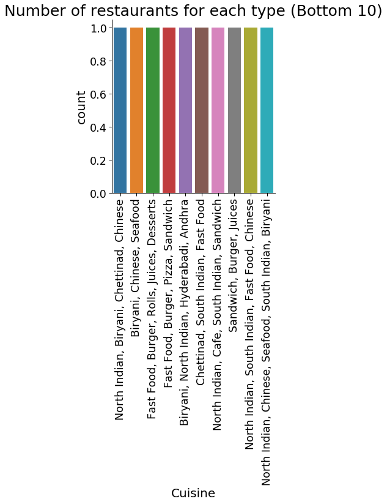

```python
sns.set_context("paper", font_scale = 2, rc = {"font.size": 20,"axes.titlesize": 25,"axes.labelsize": 20})
b = sns.catplot(data = df, kind = 'count', x = 'Cuisine', order = df['Cuisine'].value_counts().tail(10).index)
plt.title('Number of restaurants for each type (Bottom 10)')
b.set_xticklabels(rotation = 90)
plt.show()
```

Average Cost:

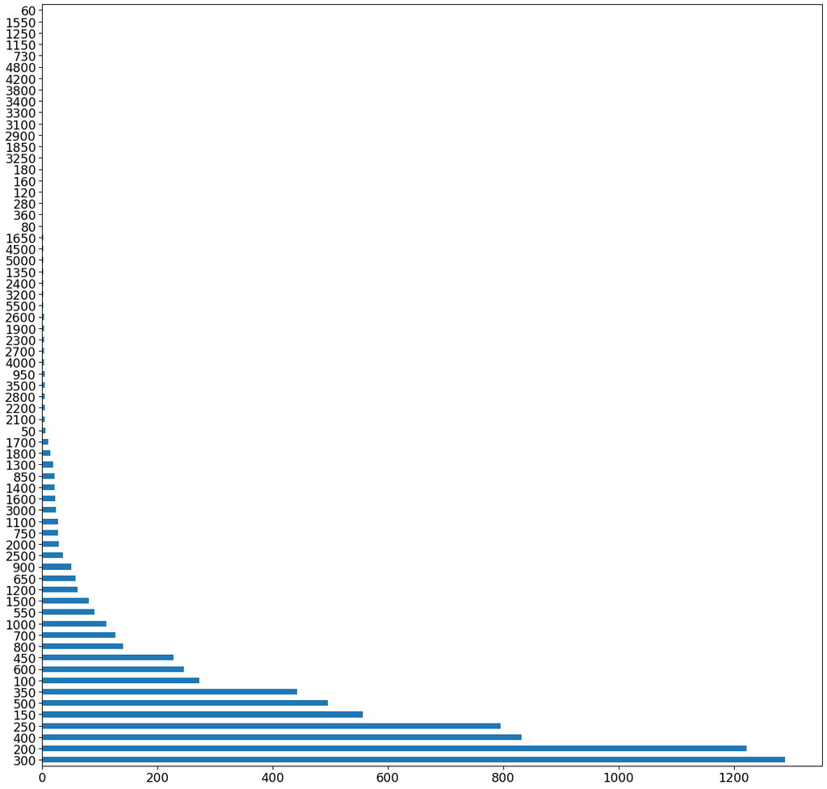

```python
import matplotlib.pyplot as plt
df['Price for 2'].value_counts().head(7442).plot(kind='barh', figsize=(20,20))
```

The majority of restaurants in Chennai have the average cost(for two) 300, followed by 200 and 400. This means that the competition is very high as far as the less costly restaurants are considered. The costlier ones are less in number and so the competition is slim.

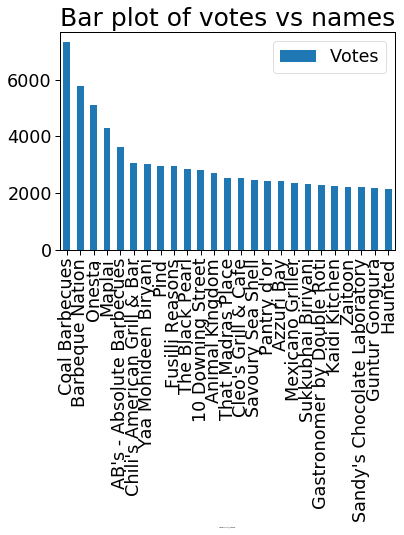

```python
df[['Votes', 'restaurant_name']].groupby(['restaurant_name']).median().sort_values("Votes", ascending = False).head(25).plot.bar()
plt.title('Bar plot of votes vs names')
plt.show()
```

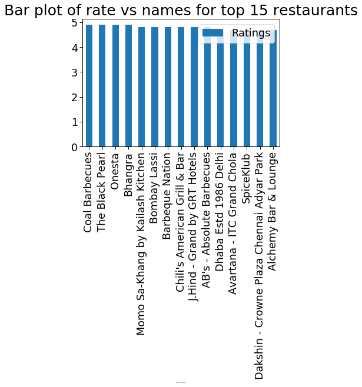

```python
df[['Ratings', 'restaurant_name']].groupby(['restaurant_name']).median().sort_values("Ratings", ascending = False).head(15).plot.bar()
plt.title('Bar plot of rate vs names for top 15 restaurants')
plt.show()
```

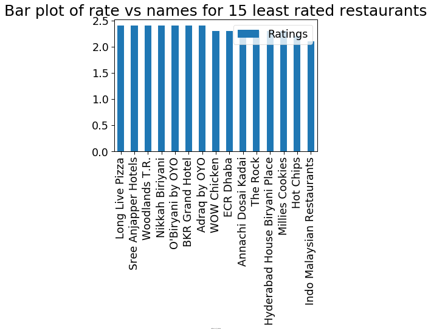

```python
a = pd.DataFrame(df['Ratings'])
a['restaurant_name'] = df['restaurant_name']
a = a.dropna(axis = 0, how ='any')
a[['Ratings', 'restaurant_name']].groupby(['restaurant_name']).median().sort_values("Ratings", ascending = False).tail(15).plot.bar()
plt.title('Bar plot of rate vs names for 15 least rated restaurants')
plt.show()
```

```python
df['Price for 2'] = df['Price for 2'].apply(lambda x: str(x).replace(',',''))
a = list(df['Price for 2'])
for i in range(0, len(a)):
    if a[i] != 'nan':
        a[i] = int(a[i])
    else:
        a[i] = None
df['Price for 2'] = a
```

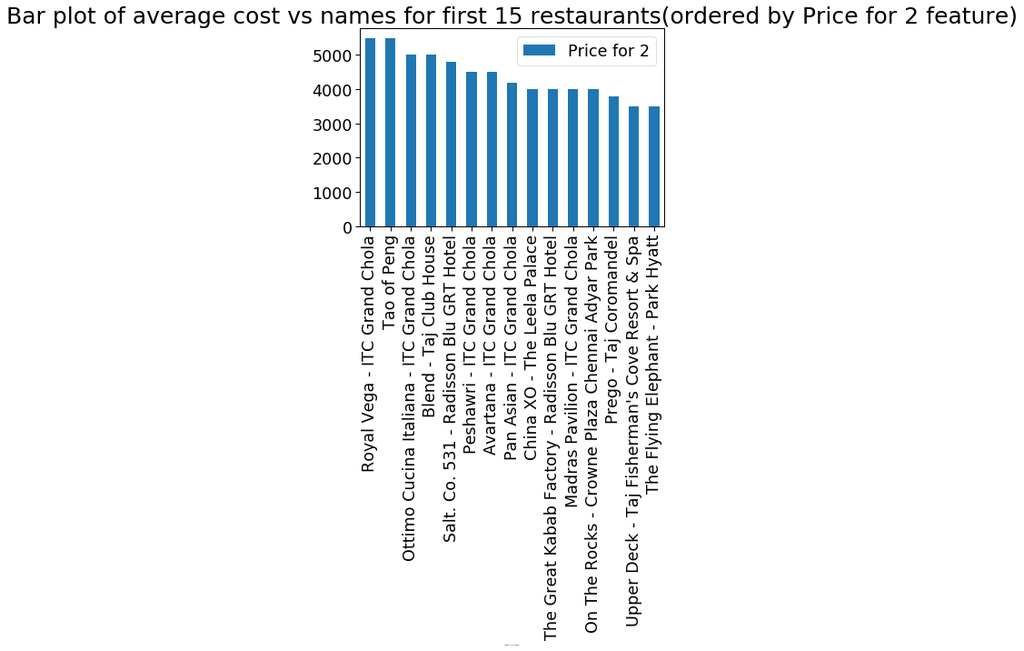

```python
df[['Price for 2', 'restaurant_name']].groupby(['restaurant_name']).median().sort_values("Price for 2", ascending = False).head(15).plot.bar()
plt.title('Bar plot of average cost vs names for first 15 restaurants(ordered by Price for 2 feature)')
plt.show()
```

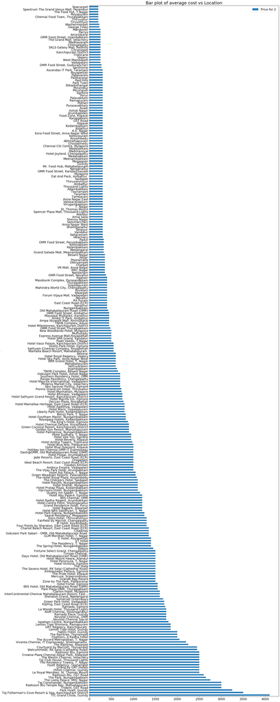

```python
df[['Price for 2', 'Location']].groupby(['Location']).median().sort_values("Price for 2", ascending = False).plot(kind='barh', figsize=(20,75))
plt.title('Bar plot of average cost vs Location')
plt.show()
```

[figure not shown]

```python
df[['Ratings', 'Location']].groupby(['Location']).median().sort_values("Ratings", ascending = False).head().plot(kind='barh', figsize=(20,20))
plt.title('Bar plot of rate vs Location')
plt.show()
```